# Coursera Practical Machine Learning Final Project

Yogesh Saletore

May 6th, 2017

Using devices such as *Jawbone Up*, *Nike FuelBand*, and *Fitbit* it is now possible to collect a large amount of data about personal activity relatively inexpensively. These type of devices are part of the quantified self movement – a group of enthusiasts who take measurements about themselves regularly to improve their health, to find patterns in their behavior, or because they are tech geeks. One thing that people regularly do is quantify how much of a particular activity they do, but they rarely quantify how well they do it.

In this project, we will use data from accelerometers on the belt, forearm, arm, and dumbell of 6 participants. They were asked to perform barbell lifts correctly and incorrectly in 5 different ways. More information is available from the website here: http://groupware.les.inf.puc-rio.br/har (see the section on the Weight Lifting Exercise Dataset).

# Data loading and Processing

## Load the data

```r
library(caret)
library(rattle)
```

```r
library(rpart)
library(rpart.plot)
library(randomForest)
library(repmis)
set.seed(1234)

all_training <- read.csv("pml-training.csv", na.strings = c("", "NA", "#DIV/0!"))
testing <- read.csv("pml-testing.csv", na.strings = c("", "NA", "#DIV/0!"))
```

## Clean the data

Remove columns with missing/unknown values.

```r
all_training <- all_training[, colSums(is.na(all_training)) == 0]
testing <- testing[, colSums(is.na(testing)) == 0]

all_training <- all_training[,-(1:5)]
testing <- testing[, -(1:5)]
```

Remove columns that have near zero variance:

```r
nzv_all_training <- nearZeroVar(all_training, saveMetrics=TRUE)
all_training <- all_training[, !nzv_all_training$nzv]

nzv_testing <- nearZeroVar(testing, saveMetrics=TRUE)
testing <- testing[, !nzv_testing$nzv]
```

## Training and Validation Data

```r
train_idx <- createDataPartition(all_training$classe, p = 0.70, list=FALSE)
training <- all_training[train_idx,]
validation <- all_training[-train_idx,]
```

# Decision Trees

Let’s try using `rpart` and Decision Trees with 5-fold cross validation.

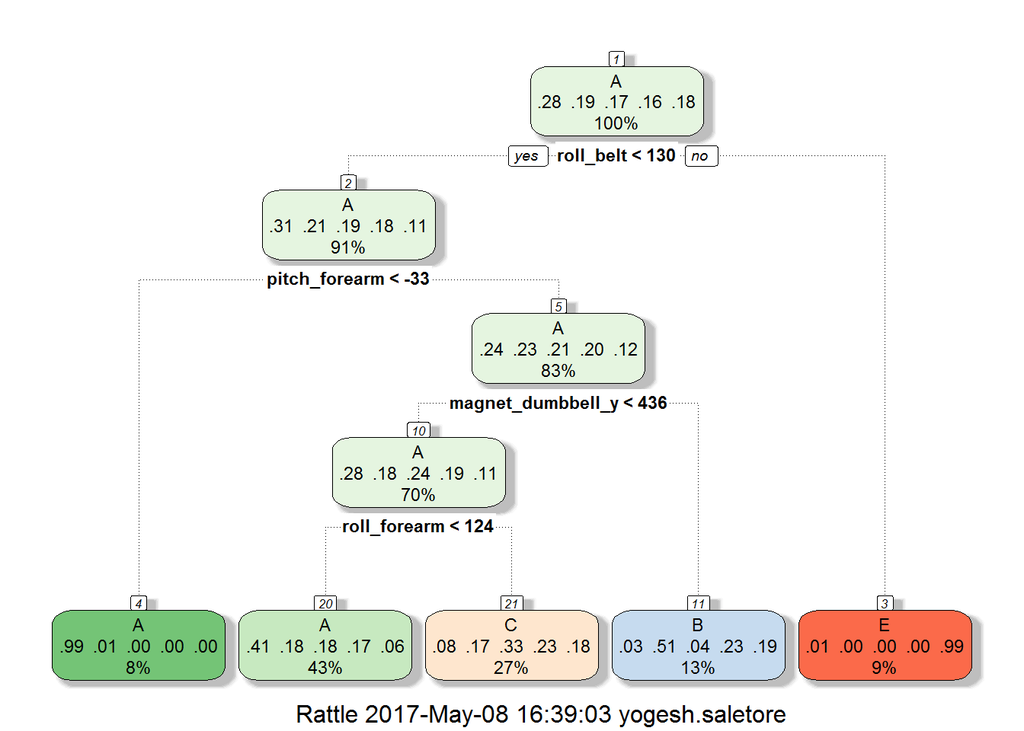

```r
trControl <- trainControl(method = "cv", number = 5)
fit_rpart <- train(classe ~ ., data = training, method = "rpart",
    trControl = trControl)
fancyRpartPlot(fit_rpart$finalModel)
```

Now see how well it performs on the validation data set:

```r
fit_rpart_predictions <- predict(fit_rpart, validation)
fit_rpart_predictions_cm <- confusionMatrix(fit_rpart_predictions, validation$classe)
fit_rpart_predictions_cm
```

```
## Confusion Matrix and Statistics
##
##           Reference
## Prediction    A    B    C    D    E
##          A 1530  486  493  452  168
##          B   35  379   31  164  145
##          C  105  274  502  348  302
##          D    0    0    0    0    0
##          E    4    0    0    0  467
##
## Overall Statistics
##
##                Accuracy : 0.489
##                  95% CI : (0.4762, 0.5019)
##     No Information Rate : 0.2845
##     P-Value [Acc > NIR] : < 2.2e-16
##
##                   Kappa : 0.3311
##  Mcnemar's Test P-Value : NA
##
## Statistics by Class:
##
##                      Class: A Class: B Class: C Class: D Class: E
## Sensitivity            0.9140   0.3327   0.4893   0.0000  0.43161
## Specificity            0.6203   0.9210   0.7882   1.0000  0.99917
## Pos Pred Value         0.4890   0.5027   0.3279      NaN  0.99151
## Neg Pred Value         0.9478   0.8519   0.8797   0.8362  0.88641
## Prevalence             0.2845   0.1935   0.1743   0.1638  0.18386
## Detection Rate         0.2600   0.0644   0.0853   0.0000  0.07935
## Detection Prevalence   0.5317   0.1281   0.2602   0.0000  0.08003
## Balanced Accuracy      0.7671   0.6269   0.6388   0.5000  0.71539
```

# Random Forest

Now let’s see if random forest regression is any better.

```r
fit_rf <- train(classe ~ ., data = training, method = "rf",
    trControl = trControl, allowParallel=TRUE, importance=TRUE)
print(fit_rf, digits = 3)
```

```
## Random Forest
##
## 13737 samples
##    53 predictor
##     5 classes: 'A', 'B', 'C', 'D', 'E'
##
## No pre-processing
## Resampling: Cross-Validated (5 fold)
## Summary of sample sizes: 10991, 10989, 10989, 10990, 10989
## Resampling results across tuning parameters:
##
##   mtry  Accuracy  Kappa
##    2    0.994     0.993
##   27    0.997     0.996
##   53    0.995     0.994
##
## Accuracy was used to select the optimal model using  the largest value.
## The final value used for the model was mtry = 27.
```

Now let’s see how well it performs on the validation set:

```r
fit_rf_predictions <- predict(fit_rf, validation)
fit_rf_predictions_cm <- confusionMatrix(fit_rf_predictions, validation$classe)
fit_rf_predictions_cm
```

```
## Confusion Matrix and Statistics
##
##           Reference
## Prediction    A    B    C    D    E
##          A 1674    3    0    0    0
##          B    0 1136    3    0    0
##          C    0    0 1023    1    0
##          D    0    0    0  963    3
##          E    0    0    0    0 1079
##
## Overall Statistics
##
##                Accuracy : 0.9983
##                  95% CI : (0.9969, 0.9992)
##     No Information Rate : 0.2845
##     P-Value [Acc > NIR] : < 2.2e-16
##
##                   Kappa : 0.9979
##  Mcnemar's Test P-Value : NA
##
## Statistics by Class:
##
##                      Class: A Class: B Class: C Class: D Class: E
## Sensitivity            1.0000   0.9974   0.9971   0.9990   0.9972
## Specificity            0.9993   0.9994   0.9998   0.9994   1.0000
## Pos Pred Value         0.9982   0.9974   0.9990   0.9969   1.0000
## Neg Pred Value         1.0000   0.9994   0.9994   0.9998   0.9994
## Prevalence             0.2845   0.1935   0.1743   0.1638   0.1839
## Detection Rate         0.2845   0.1930   0.1738   0.1636   0.1833
## Detection Prevalence   0.2850   0.1935   0.1740   0.1641   0.1833
## Balanced Accuracy      0.9996   0.9984   0.9984   0.9992   0.9986
```

The random forest model achieves an accuracy of 99.83%, with an out of sample error of only 0.17%, much better than the earlier decision tree method.

# Use Random Forest Model on Test Data Set

```r
fit_rf_test_predictions <- predict(fit_rf, testing)
fit_rf_test_predictions
```

```
##  [1] B A B A A E D B A A B C B A E E A B B B
## Levels: A B C D E
```